# Random Numbers and Probability

by Edneide Ramalho

31/07/2021

# 1 Sampling from a data frame

```r
library(dplyr)
name <- c("Amir", "Brian", "Claire", "Damian")
n_sales <- c(178, 126, 75, 69)
sales_counts <- tibble::tibble(name = name,
                               n_sales = n_sales)
```

```r
set.seed(5)
sales_counts %>%
  sample_n(1)
```

```
## # A tibble: 1 x 2
##   name  n_sales
##   <chr>   <dbl>
## 1 Brian     126
```

```r
set.seed(5)
sales_counts %>%
  sample_n(2)
```

```
## # A tibble: 2 x 2
##   name   n_sales
##   <chr>    <dbl>
## 1 Brian      126
## 2 Claire      75
```

```r
sales_counts %>%
  sample_n(2, replace = TRUE)
```

```
## # A tibble: 2 x 2
##   name   n_sales
##   <chr>    <dbl>
## 1 Amir       178
## 2 Claire      75
```

```r
sample(sales_counts, 5, replace = TRUE)
```

```
## # A tibble: 4 x 5
##   name   name   name   name   n_sales
##   <chr>  <chr>  <chr>  <chr>    <dbl>
## 1 Amir   Amir   Amir   Amir       178
## 2 Brian  Brian  Brian  Brian      126
## 3 Claire Claire Claire Claire      75
## 4 Damian Damian Damian Damian      69
```

```r
library(readr)
seller_1 <- read_csv("data/seller_1.csv")
# Count the dealsfor each product
amir_deals <- seller_1
amir_deals %>%
  count(product)
```

```
## # A tibble: 11 x 2
##    product       n
##    <chr>     <int>
##  1 Product A    23
##  2 Product B    62
##  3 Product C    15
##  4 Product D    40
##  5 Product E     5
##  6 Product F    11
##  7 Product G     2
##  8 Product H     8
##  9 Product I     7
## 10 Product J     2
## 11 Product N     3
```

- Create a new column called `prob` by dividing `n` by the total number of deals Amir worked on.

```r
amir_deals %>%
  count(product) %>%
  mutate(prob = n/sum(n))
```

```
## # A tibble: 11 x 3
##    product       n   prob
##    <chr>     <int>  <dbl>
##  1 Product A    23 0.129
##  2 Product B    62 0.348
##  3 Product C    15 0.0843
##  4 Product D    40 0.225
##  5 Product E     5 0.0281
##  6 Product F    11 0.0618
##  7 Product G     2 0.0112
##  8 Product H     8 0.0449
##  9 Product I     7 0.0393
## 10 Product J     2 0.0112
## 11 Product N     3 0.0169
```

- Set the random seed to `31`.
- Take a sample of 5 deals **without** replacement.

```r
# Set random seed to 31
set.seed(31)

# Sample 5 deals without replacement
amir_deals %>%
  sample_n(5, replace = FALSE)
```

```
## # A tibble: 5 x 5
##   product   client  status amount num_users
##   <chr>     <chr>   <chr>   <dbl>     <dbl>
## 1 Product D Current Lost    3087.        55
## 2 Product C Current Lost    3728.        19
## 3 Product D Current Lost    4275.         9
## 4 Product B Current Won     4965.         9
## 5 Product A Current Won     5827.        50
```

- Take a sample of 5 deals **with** replacement.

```r
# Set random seed to 31
set.seed(31)

# Sample 5 deals with replacement
amir_deals %>%
  sample_n(5, replace = TRUE)
```

[output not shown]

# 2 Discrete distributions

## 2.1 Creating a probability distribution

A new restaurant opened a few months ago, and the restaurant’s management wants to optimize its seating space based on the size of the groups that come most often. On one night, there are 10 groups of people waiting to be seated at the restaurant, but instead of being called in the order they arrived, they will be called randomly. In this exercise, you’ll investigate the probability of groups of different sizes getting picked first. Data on each of the ten groups is contained in the restaurant_groups data frame.

Remember that expected value can be calculated by multiplying each possible outcome with its corresponding probability and taking the sum. The restaurant_groups data is available and dplyr and ggplot2 are loaded.

```r
library(readr)
restaurant_groups <- read_csv("restaurant_groups.csv")
```

- Create a histogram of the group_size column of restaurant_groups, setting the number of bins to 5.

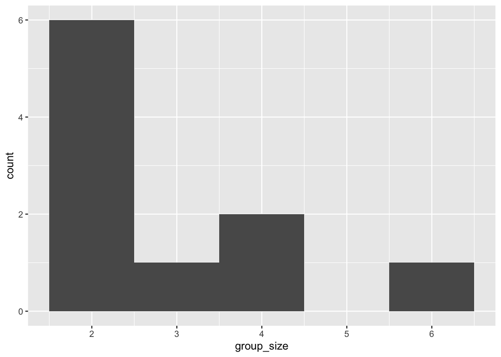

```r
library(ggplot2)
ggplot(restaurant_groups, aes(x = group_size)) +
  geom_histogram(bins = 5)
```

Count the number of each group_size in restaurant_groups, then add a column called probability that contains the probability of randomly selecting a group of each size. Store this in a new data frame called size_distribution.

```r
# Create probability distribution
size_distribution <- restaurant_groups %>%
  # Count number of each group size
  count(group_size) %>%
  # Calculate probability
  mutate(probability = n / sum(n))

size_distribution
```

```
## # A tibble: 4 x 3
##   group_size     n probability
##        <dbl> <int>       <dbl>
## 1          2     6         0.6
## 2          3     1         0.1
## 3          4     2         0.2
## 4          6     1         0.1
```

Calculate the expected value of the size_distribution, which represents the expected group size.

```r
# Create probability distribution
size_distribution <- restaurant_groups %>%
  count(group_size) %>%
  mutate(probability = n / sum(n))

# Calculate expected group size
expected_val <- sum(size_distribution$group_size *
                    size_distribution$probability)
expected_val
```

```
## [1] 2.9
```

Calculate the probability of randomly picking a group of 4 or more people by filtering and summarizing.

```r
# Create probability distribution
size_distribution <- restaurant_groups %>%
  count(group_size) %>%
  mutate(probability = n / sum(n))

# Calculate probability of picking group of 4 or more
size_distribution %>%
  # Filter for groups of 4 or larger
  filter(group_size >= 4) %>%
  # Calculate prob_4_or_more by taking sum of probabilities
  summarize(prob_4_or_more = sum(probability))
```

```
## # A tibble: 1 x 1
##   prob_4_or_more
##            <dbl>
## 1            0.3
```

# 3 Continuous Distribution

## 3.1 Uniform distribution

```r
# Probability of wait time <= 7
punif(7, min = 0, max = 12)
```

```
## [1] 0.5833333
```

```r
# Probability of wait time >= 7
punif(7, min = 0, max = 12, lower.tail = FALSE)
```

```
## [1] 0.4166667
```

- $P(4 \leq \text{wait time} \leq 7 )$

```r
punif(7, min = 0, max = 12) - punif(4, min = 0, max = 12)
```

```
## [1] 0.25
```

## 3.2 Data back-ups

The sales software used at your company is set to automatically back itself up, but no one knows exactly what time the back-ups happen. It is known, however, that back-ups happen exactly every 30 minutes. Amir comes back from sales meetings at random times to update the data on the client he just met with. He wants to know how long he’ll have to wait for his newly-entered data to get backed up. Use your new knowledge of continuous uniform distributions to model this situation and answer Amir’s questions.

To model how long Amir will wait for a back-up using a continuous uniform distribution, save his lowest possible wait time as min and his longest possible wait time as max. Remember that back-ups happen every 30 minutes.

```r
# Min and max wait times for back-up that happens every 30 min
min <- 0
max <- 30
```

Calculate the probability that Amir has to wait less than 5 minutes, and store in a variable called prob_less_than_5.

```r
# Calculate probability of waiting less than 5 mins
prob_less_than_5 <- punif(5, min, max)
prob_less_than_5
```

```
## [1] 0.1666667
```

Calculate the probability that Amir has to wait more than 5 minutes, and store in a variable called prob_greater_than_5.

```r
# Calculate probability of waiting more than 5 mins
prob_greater_than_5 <- punif(5, min, max, lower.tail = FALSE)
prob_greater_than_5
```

```
## [1] 0.8333333
```

Calculate the probability that Amir has to wait between 10 and 20 minutes, and store in a variable called prob_between_10_and_20.

```r
# Calculate probability of waiting 10-20 mins
prob_between_10_and_20 <- punif(20, min, max) - punif(10, min, max)
prob_between_10_and_20
```

```
## [1] 0.3333333
```

## 3.3 The binomial distribution

```r
simulation_nb <- seq(1, 1000)
```

```r
set.seed(334)
```

Generate 1000 wait times from the continuous uniform distribution that models Amir’s wait time. Add this as a new column called time in the wait_times data frame.

```r
time <- runif(1000, min, max)
```

```r
wait_times <- tibble(simulation_nb = simulation_nb,
                     time = time)
```

Create a histogram of the simulated wait times with 30 bins.

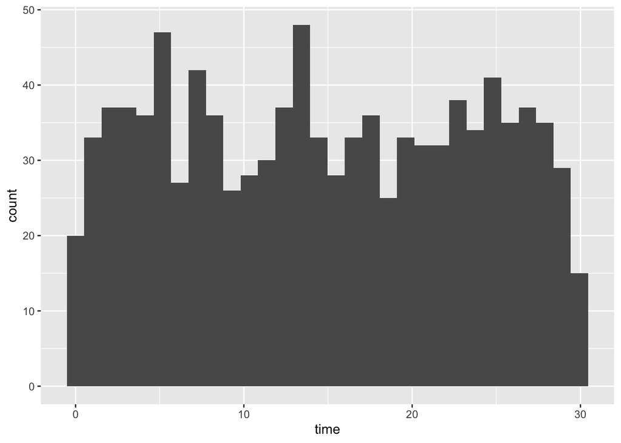

```r
# Generate 1000 wait times between 0 and 30 mins, save in time column
wait_times %>%
  mutate(time = runif(1000, min = 0, max = 30)) %>%
  # Create a histogram of simulated times
  ggplot(aes(time)) +
  geom_histogram(bins = 30)
```

- Binary outcome: 0 or 1, Head and Tails.
- Simulation in R:
- fliping one coin

```r
rbinom(1, 1, 0.5)
```

```
## [1] 1
```

- fliping 8 coins

```r
rbinom(8, 1, 0.5)
```

```
## [1] 0 0 0 0 0 0 0 1
```

- 10 flips

```r
rbinom(10, 1, 0.5)
```

```
##  [1] 1 0 0 1 1 1 0 1 0 0
```

- What’s the probability of 7 heads?

$$P(\text{heads} = 7)$$

```r
# dbinom(num head, num trials, prob of heads)
dbinom(7, 10, 0.5)
```

```
## [1] 0.1171875
```

- What’s the probability of 7 or fewer heads?
  $$P(\text{heads} \leq 7)$$

```r
pbinom(7, 10, 0.5)
```

```
## [1] 0.9453125
```

- What’s the probability of more than 7 heads?

$$P(\text{heads} > 7)$$

```r
pbinom(7, 10, 0.5, lower.tail = FALSE)
```

```
## [1] 0.0546875
```

```r
# the same as
1 - pbinom(7, 10, 0.5)
```

```
## [1] 0.0546875
```

## 3.4 Exercises

### 3.4.1 Simulating sales deals

Assume that Amir usually works on 3 deals per week, and overall, he wins 30% of deals he works on. Each deal has a binary outcome: it’s either lost, or won, so you can model his sales deals with a binomial distribution. In this exercise, you’ll help Amir simulate a year’s worth of his deals so he can better understand his performance.

1. Set the random seed to 10 and simulate a single deal.

```r
# Set random seed to 10
set.seed(10)

# Simulate a single deal
rbinom(1, 1, 0.3)
```

```
## [1] 0
```

2. Simulate a typical week of Amir’s deals, or one week of 3 deals.

```r
# Set random seed to 10
set.seed(10)

# Simulate 1 week of 3 deals
rbinom(1, 3, 0.3)
```

```
## [1] 1
```

3. Simulate a year’s worth of Amir’s deals, or 52 weeks of 3 deals each, and store in deals.

```r
# Set random seed to 10
set.seed(10)

# Simulate 52 weeks of 3 deals
deals <- rbinom(52, 3, 0.3)

# Calculate mean deals won per week
mean(deals)
```

```
## [1] 0.8076923
```

### 3.4.2 Calculating binomial probabilities

Just as in the last exercise, assume that Amir wins 30% of deals. He wants to get an idea of how likely he is to close a certain number of deals each week. In this exercise, you’ll calculate what the chances are of him closing different numbers of deals using the binomial distribution.

1. What’s the probability that Amir closes all 3 deals in a week?

```r
# Probability of closing 3 out of 3 deals
dbinom(3, 3, 0.3)
```

```
## [1] 0.027
```

2. What’s the probability that Amir closes 1 or fewer deals in a week?

```r
# Probability of closing <= 1 deal out of 3 deals
pbinom(1, 3, 0.3)
```

```
## [1] 0.784
```

3. What’s the probability that Amir closes more than 1 deal?

```r
# Probability of closing > 1 deal out of 3 deals
pbinom(1, 3, 0.3, lower.tail = FALSE)
```

```
## [1] 0.216
```

### 3.4.3 How many sales will be won?

Now Amir wants to know how many deals he can expect to close each week if his win rate changes. Luckily, you can use your binomial distribution knowledge to help him calculate the expected value in different situations. Recall from the video that the expected value of a binomial distribution can be calculated by $n \times p$.

- Calculate the expected number of sales out of the 3 he works on that Amir will win each week if he maintains his 30% win rate.
- Calculate the expected number of sales out of the 3 he works on that he’ll win if his win rate drops to 25%.
- Calculate the expected number of sales out of the 3 he works on that he’ll win if his win rate rises to 35%.

```r
# Expected number won with 30% win rate
won_30pct <- 3 * 0.3
won_30pct
```

```
## [1] 0.9
```

```r
# Expected number won with 25% win rate
won_25pct <- 3 * 0.25
won_25pct
```

```
## [1] 0.75
```

```r
# Expected number won with 35% win rate
won_35pct <- 3 * 0.35
won_35pct
```

```
## [1] 1.05
```

## 3.5 The Normal distribution

### 3.5.1 Characteristics

- Bell curve
- It is symmetrical
- Area beneath the curve is one
- P ≥ 0

### 3.5.2 Standard Normal distribution

- Mean = 0
- SD = 1
- 99.7% of the area falls within 3 standard deviations

### 3.5.3 Examples

- Women’s height
- P(height < 154 cm)

```r
pnorm(154, mean = 161, sd = 7)
```

```
## [1] 0.1586553
```

- P(height > 154 cm)

```r
pnorm(154, mean = 161, sd = 7, lower.tail = FALSE)
```

```
## [1] 0.8413447
```

- What height are 90% of women shorter than?

```r
qnorm(0.9, mean = 161, sd = 7)
```

```
## [1] 169.9709
```

90% of women are shorter than 170 cm.

### 3.5.4 Generating random numbers

```r
rnorm(10, mean = 161, sd = 7)
```

```
##  [1] 156.1871 154.8949 160.2877 159.2235 148.0238 160.4544 167.7800 162.2945
##  [9] 151.3404 150.9514
```

### 3.5.5 Exercises

#### 3.5.5.1 Distribution of Amir’s sales

Since each deal Amir worked on (both won and lost) was different, each was worth a different amount of money. These values are stored in the amount column of amir_deals As part of Amir’s performance review, you want to be able to estimate the probability of him selling different amounts, but before you can do this, you’ll need to determine what kind of distribution the amount variable follows.

Both dplyr and ggplot2 are loaded and amir_deals is available.

```r
library(readr)
amir_deals <- read_csv("data/amir_deals.csv")
glimpse(amir_deals)
```

```
## Rows: 178
## Columns: 6
## $ X1        <dbl> 1, 2, 3, 4, 5, 6, 7, 8, 9, 10, 11, 12, 13, 14, 15, 16, 17, 1…
## $ product   <chr> "Product F", "Product C", "Product B", "Product I", "Product…
## $ client    <chr> "Current", "New", "New", "Current", "Current", "New", "Curre…
## $ status    <chr> "Won", "Won", "Won", "Won", "Won", "Won", "Won", "Won", "Won…
## $ amount    <dbl> 7389.52, 4493.01, 5738.09, 2591.24, 6622.97, 5496.27, 3043.1…
## $ num_users <dbl> 19, 43, 87, 83, 17, 2, 29, 13, 80, 23, 26, 6, 15, 43, 41, 12…
```

```r
amir_deals <- amir_deals[, -1]
```

- Create a histogram with 10 bins to visualize the distribution of the amount.

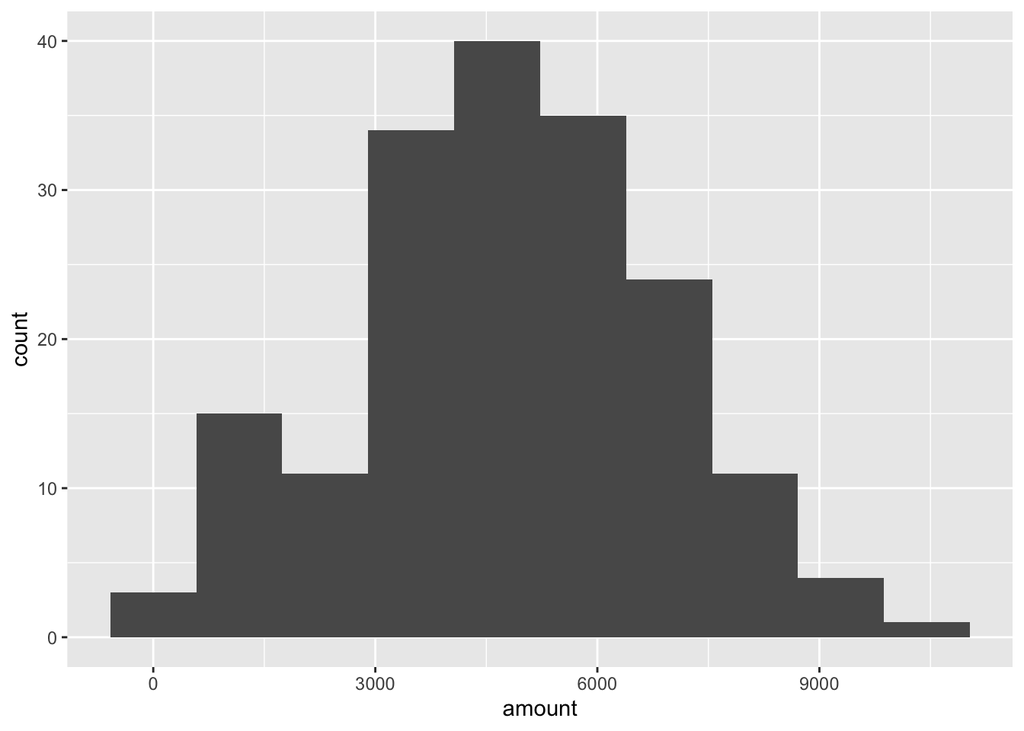

```r
amir_deals %>%
  ggplot(aes(x = amount)) +
  geom_histogram(bins = 10)
```

Amir`s amount follow, approximately, a normal distribution.

#### 3.5.5.2 Probabilities from the normal distribution

Since each deal Amir worked on (both won and lost) was different, each was worth a different amount of money. These values are stored in the amount column of amir_deals and follow a normal distribution with a mean of 5000 dollars and a standard deviation of 2000 dollars. As part of his performance metrics, you want to calculate the probability of Amir closing a deal worth various amounts.

- What’s the probability of Amir closing a deal worth less than $7500?

```r
pnorm(7500, mean = 5000, sd = 2000)
```

```
## [1] 0.8943502
```

There is a 89.43% probability that Amil closes a deal worthing less than or equal to $7500.

- What’s the probability of Amir closing a deal worth more than $1000?

```r
pnorm(1000, mean = 5000, sd = 2000, lower.tail = FALSE)
```

```
## [1] 0.9772499
```

There is a 97.72% probability that Amil closes a deal worthing more than or equal to $1000.

- What’s the probability of Amir closing a deal worth between `$3000` and `$7000`?